```python
import numpy as np
import pandas as pd
import matplotlib.pyplot as plt
import seaborn as sns
import plotly.express as px
from scipy.stats import norm
import plotly.graph_objects as go
import plotly.figure_factory as ff
# Draw inline
%matplotlib inline

# Set figure aesthetics
sns.set_style("white", {'ytick.major.size': 10.0})
sns.set_context("poster", font_scale=1.1)
import warnings
warnings.filterwarnings('ignore')
```

# FUNCTIONS

```python
def affiliatePlot(df,hue,title):
  plt.figure(figsize=(14,10))
  order1 = df['account_year'].value_counts().index
  fig = sns.countplot(data = df,x='account_year' ,order = order1,hue=hue)
  fig.legend(loc='center left', bbox_to_anchor=(1.25, 0.5), ncol=1)
  plt.xlabel('Year')
  plt.ylabel('Count')
  plt.title(title)
  order2 = df['account_year'].value_counts()

def countPlot(df,x,xlabel,title,size):
  plt.figure(figsize=(size[0],size[1]))
  Order = df[x].value_counts().index
  sns.countplot(data = df, x = x, order = Order)
  plt.xlabel(xlabel)
  plt.ylabel('Count')
  plt.title(title)
  order2 = df[x].value_counts()

  for i in range(order2.shape[0]):
    count = order2[i]
    strt='{:0.1f}%'.format(100*count / df.shape[0])
    plt.text(i,count+1000,strt,ha='center')

def countplotWithHue(df,x,xlabel,title,size,hue):
  plt.figure(figsize=(size[0],size[1]))
  order1 = df[x].value_counts().index
  fig = sns.countplot(data = df, x = x, order = order1,hue=hue)
  fig.legend(loc='center left', bbox_to_anchor=(.75, 0.5), ncol=1)
  plt.xlabel(xlabel)
  plt.ylabel('Count')
  plt.title(title)
  order2 = df[x].value_counts()

def boxPlot(df,y,x,size,xlabel,ylabel,title):
  plt.figure(figsize=[size[0],size[1]])
  sns.boxplot(data=df,y=y,x=x);
  plt.ylim(18,110)
  plt.xlabel(xlabel);
  plt.ylabel(ylabel);
  plt.title(title);
```

# data visualization

## Age-gender Database

```python
df_Age_Population = pd.read_csv("/content/drive/My Drive/vodafoneTask/datasets/dataset-modified/age-gender-population.csv");
df_Age_Population.head()
```

|  | country_destination | gender | population_in_thousands | mean_age |
| --- | --- | --- | --- | --- |
| 0 | AU | male | 1.0 | 102.0 |
| 1 | AU | male | 9.0 | 97.0 |
| 2 | AU | male | 47.0 | 92.0 |
| 3 | AU | male | 118.0 | 87.0 |
| 4 | AU | male | 199.0 | 82.0 |

### Gender distribution

```python
male_count = [df_Age_Population.loc[df_Age_Population.gender  == 'male']['population_in_thousands'].sum()]
female_count = [df_Age_Population.loc[df_Age_Population.gender  == 'female']['population_in_thousands'].sum()]
type(male_count)
```

```
list
```

```python
fig = go.Figure()
fig.add_trace(go.Bar(
    x=['male'],
    y= male_count,
     width=[0.4],
    name='Male',
     marker_color='rgb(41, 46, 82)'
))
fig.add_trace(go.Bar(
    x=['female'],
    y=female_count,
    name='Female',
    marker_color='rgb(86, 114, 148)',
  width=[0.4]
))

fig.update_layout(
    title='Gender distribution',
    xaxis_tickfont_size=14,
    yaxis=dict(
        title='population',
        titlefont_size=20,
        tickfont_size=16,
    ),
    legend=dict(
        x=0,
        y=1.0,
        bgcolor='rgba(255, 255, 255, 0)',
        bordercolor='rgba(255, 255, 255, 0)'
    ),
)
fig.show()
```

[interactive chart not shown]

### gender & mean Age

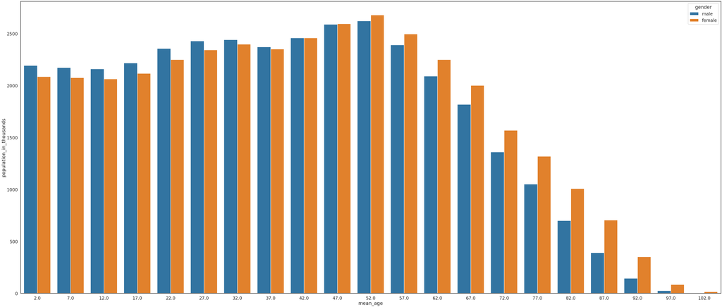

```python
plt.figure(figsize=(70,30))
sns.barplot(x='mean_age', y='population_in_thousands', hue='gender', data=df_Age_Population, ci=None)
```

## seesion data

```python
df_seesions = pd.read_csv('/content/drive/My Drive/vodafoneTask/datasets/dataset-modified/sessions-v1.csv')
df_seesions.head()
```

|  | user_id | action | action_type | action_detail | device_type | secs_elapsed |
| --- | --- | --- | --- | --- | --- | --- |
| 0 | d1mm9tcy42 | lookup | NaN | NaN | Windows Desktop | 319.0 |
| 1 | d1mm9tcy42 | search_results | click | view_search_results | Windows Desktop | 67753.0 |
| 2 | d1mm9tcy42 | lookup | NaN | NaN | Windows Desktop | 301.0 |
| 3 | d1mm9tcy42 | search_results | click | view_search_results | Windows Desktop | 22141.0 |
| 4 | d1mm9tcy42 | lookup | NaN | NaN | Windows Desktop | 435.0 |

```python
df_seesions.isnull().sum()
```

```
user_id            34496
action             79626
action_type      2157374
action_detail    2157345
device_type            0
secs_elapsed      136031
dtype: int64
```

```python
df_seesions.action_type.unique()
```

```
array([nan, 'click', 'data', 'view', 'submit', 'message_post',
       'booking_request', 'partner_callback', 'booking_response',
       'modify'], dtype=object)
```

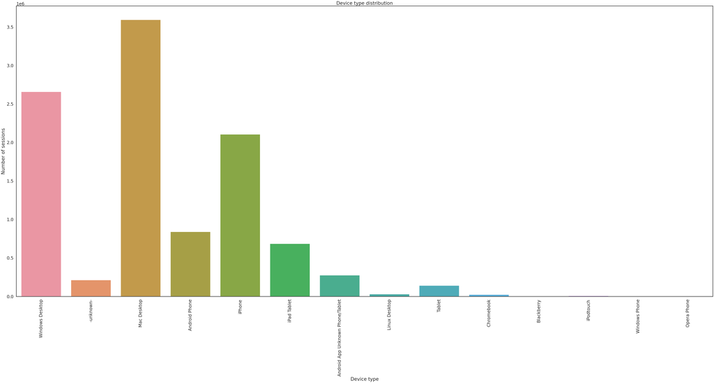

```python
plt.figure(figsize=(70,30))
sns.countplot(x='device_type', data=df_seesions)
plt.xlabel('Device type')
plt.ylabel('Number of sessions')
plt.title('Device type distribution')
plt.xticks(rotation=90)
plt.show()
```

**The Mac Desktop is the most popular device among Airbnb Users, followed by the Windows Desktop. An interesting insight is that Apple Products are extremely popular with Airbnb Users. The iPhone, iPad and the Mac all appear in the list of top 5 most popular devices.**

## Main datasets (train &test)

```python
all_users = pd.read_csv('/content/drive/My Drive/vodafoneTask/datasets/mainDatasetVisual/all_users-visualization.csv')
train_users = pd.read_csv('/content/drive/My Drive/vodafoneTask/datasets/mainDatasetVisual/train_users-visualization.csv')
all_users.head()
```

|  | affiliate_channel | affiliate_provider | age | date_account_created | first_affiliate_tracked | first_browser | first_device_type | gender | language | signup_app | signup_flow | signup_method | timestamp_first_active |
| --- | --- | --- | --- | --- | --- | --- | --- | --- | --- | --- | --- | --- | --- |
| 0 | direct | direct | NaN | 2010-06-28 | untracked | Chrome | Mac Desktop | -unknown- | en | Web | 0 | facebook | 2009-03-19 04:32:55 |
| 1 | seo | google | 38.0 | 2011-05-25 | untracked | Chrome | Mac Desktop | MALE | en | Web | 0 | facebook | 2009-05-23 17:48:09 |
| 2 | direct | direct | 56.0 | 2010-09-28 | untracked | IE | Windows Desktop | FEMALE | en | Web | 3 | basic | 2009-06-09 23:12:47 |
| 3 | direct | direct | 42.0 | 2011-12-05 | untracked | Firefox | Mac Desktop | FEMALE | en | Web | 0 | facebook | 2009-10-31 06:01:29 |
| 4 | direct | direct | 41.0 | 2010-09-14 | untracked | Chrome | Mac Desktop | -unknown- | en | Web | 0 | basic | 2009-12-08 06:11:05 |

### country destination distribution

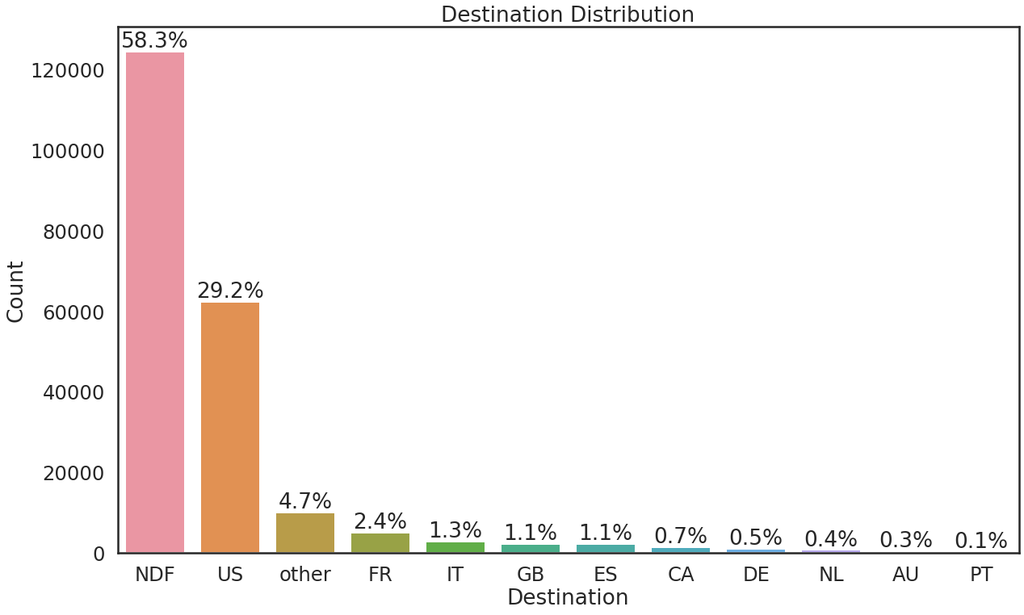

```python
countPlot(train_users,'country_destination','Destination','Destination Distribution',[20,12])
```

**nearly 60% of the users did not end up booking any trip represented by NDF. A majority of users booked a destination in US (about 30%) considering that user population in this problem is from US. Thus, my inference is that US travelers tend to travel within US itself.**

### gender distribution

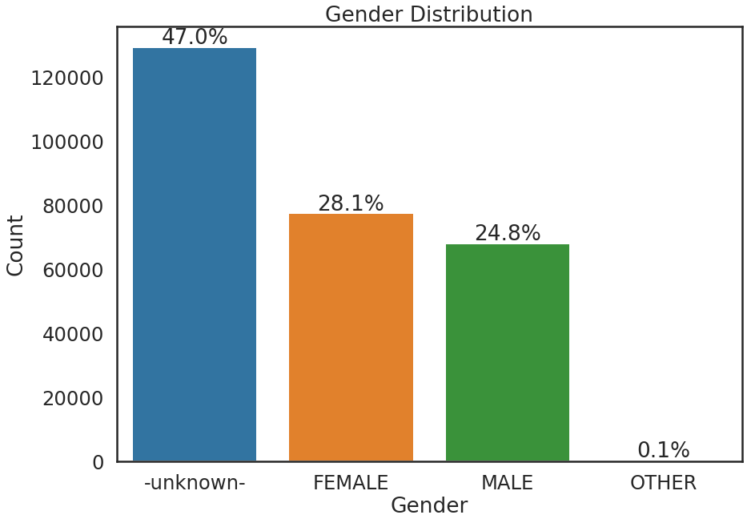

```python
countPlot(all_users,'gender','Gender','Gender Distribution',[14,10])
```

```python
train_NDF =train_users[train_users['country_destination'] =='NDF']
```

```python
user_No_book =train_NDF.groupby('gender').size().to_dict()
user_No_book
```

```
{'-unknown-': 66670, 'FEMALE': 31048, 'MALE': 26719, 'OTHER': 106}
```

```python
train_NotNDF =train_users[train_users['country_destination']!='NDF']
```

```python
user_book = train_NotNDF.groupby('gender').size() .to_dict()
user_book
```

```
{'-unknown-': 29018, 'FEMALE': 31993, 'MALE': 27721, 'OTHER': 176}
```

```python
df_user_book = pd.DataFrame(user_book.items(), columns=['gender', 'count'])
book_count=[df_user_book.sum()][0]['count']
```

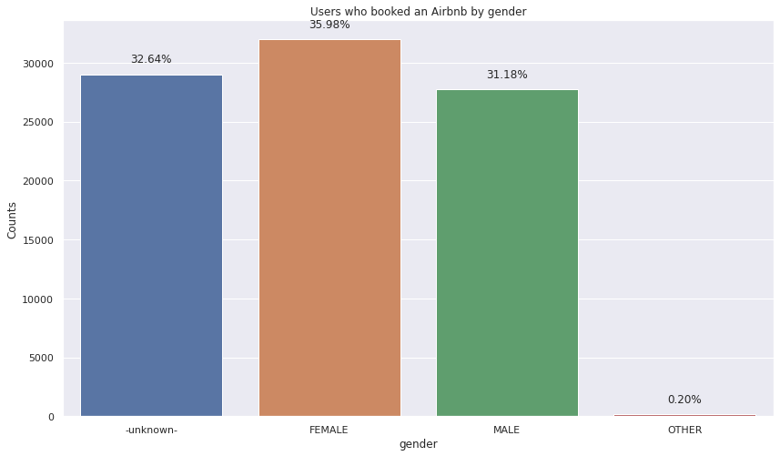

```python
plt.figure(figsize=[14,8])
sns.barplot(data=df_user_book,x='gender',y='count');
plt.title('Users who booked an Airbnb by gender');
plt.xlabel('gender')
plt.ylabel('Counts')
for i in range(df_user_book.shape[0]):
    count=df_user_book.iloc[i]['count']
    strt='{:0.2f}%'.format(100*count/book_count)
    plt.text(i,count+1000,strt,ha='center')
```

```python
df_user_No_book = pd.DataFrame(user_No_book.items(), columns=['gender', 'count'])
No_book_count=[df_user_No_book.sum()][0]['count']
```

[figure not shown]

```python
plt.figure(figsize=[14,8])
sns.barplot(data=df_user_No_book,x='gender',y='count');
plt.title('Users who didn\'t book an Airbnb by gender');
plt.xlabel('gender')
plt.ylabel('Counts')
for i in range(df_user_No_book.shape[0]):
    count=df_user_No_book.iloc[i]['count']
    strt='{:0.2f}%'.format(100*count/No_book_count)
    plt.text(i,count+1000,strt,ha='center')
```

One very interesting point of note is that people who haven't marked their gender are less likely to book an Airbnb

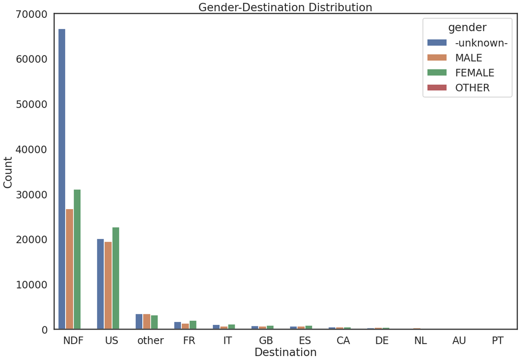

```python
plt.figure(figsize=(20,14))
order1 = train_users['country_destination'].value_counts().index
sns.countplot(data = train_users, x = 'country_destination', order = order1,hue='gender')
plt.xlabel('Destination')
plt.ylabel('Count')
plt.title('Gender-Destination Distribution')
order2 = train_users['country_destination'].value_counts()
```

### date distrbution

```python
all_users.head()
```

|  | affiliate_channel | affiliate_provider | age | date_account_created | first_affiliate_tracked | first_browser | first_device_type | gender | language | signup_app | signup_flow | signup_method | timestamp_first_active | account_year |
| --- | --- | --- | --- | --- | --- | --- | --- | --- | --- | --- | --- | --- | --- | --- |
| 0 | direct | direct | NaN | 2010-06-28 | untracked | Chrome | Mac Desktop | -unknown- | en | Web | 0 | facebook | 2009-03-19 04:32:55 | 2010 |
| 1 | seo | google | 38.0 | 2011-05-25 | untracked | Chrome | Mac Desktop | MALE | en | Web | 0 | facebook | 2009-05-23 17:48:09 | 2011 |
| 2 | direct | direct | 56.0 | 2010-09-28 | untracked | IE | Windows Desktop | FEMALE | en | Web | 3 | basic | 2009-06-09 23:12:47 | 2010 |
| 3 | direct | direct | 42.0 | 2011-12-05 | untracked | Firefox | Mac Desktop | FEMALE | en | Web | 0 | facebook | 2009-10-31 06:01:29 | 2011 |
| 4 | direct | direct | 41.0 | 2010-09-14 | untracked | Chrome | Mac Desktop | -unknown- | en | Web | 0 | basic | 2009-12-08 06:11:05 | 2010 |

```python
all_users['date_account_created']=pd.to_datetime(all_users['date_account_created'])
```

```python
all_users['account_year'] = all_users['date_account_created'].dt.year
```

```python
df = all_users.groupby('account_year').count()
df.head()
years = [2010,2011,2012,2013,2014]
yearsOrder=pd.api.types.CategoricalDtype(ordered=True, categories=years)
df.reset_index(inplace = True)
df.acc_year = df.account_year.astype(yearsOrder)
```

```python
df.head()
```

|  | account_year | affiliate_channel | affiliate_provider | age | date_account_created | first_affiliate_tracked | first_browser | first_device_type | gender | language | signup_app | signup_flow | signup_method | timestamp_first_active |
| --- | --- | --- | --- | --- | --- | --- | --- | --- | --- | --- | --- | --- | --- | --- |
| 0 | 2010 | 2788 | 2788 | 1643 | 2788 | 2003 | 2788 | 2788 | 2788 | 2788 | 2788 | 2788 | 2788 | 2788 |
| 1 | 2011 | 11775 | 11775 | 7597 | 11775 | 9382 | 11775 | 11775 | 11775 | 11775 | 11775 | 11775 | 11775 | 11775 |
| 2 | 2012 | 39462 | 39462 | 25463 | 39462 | 38155 | 39462 | 39462 | 39462 | 39462 | 39462 | 39462 | 39462 | 39462 |
| 3 | 2013 | 82960 | 82960 | 47649 | 82960 | 82175 | 82960 | 82960 | 82960 | 82960 | 82960 | 82960 | 82960 | 82960 |
| 4 | 2014 | 138562 | 138562 | 75291 | 138562 | 137747 | 138562 | 138562 | 138562 | 138562 | 138562 | 138562 | 138562 | 138562 |

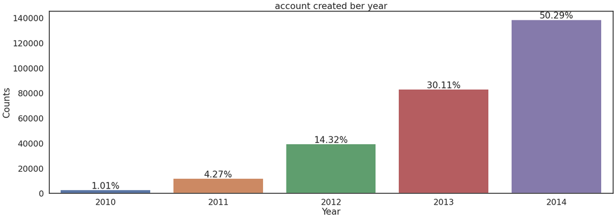

```python
plt.figure(figsize=[30,10])
sns.barplot(data=df,x='account_year',y='affiliate_provider');
plt.title('account created ber year');
plt.xlabel('Year')
plt.ylabel('Counts')
for i in range(df.shape[0]):
    count=df.iloc[i]['affiliate_provider']
    strt='{:0.2f}%'.format(100*count/all_users.shape[0])
    plt.text(i,count+1000,strt,ha='center')
```

```python
train_users['account_year'] =all_users['account_year']
```

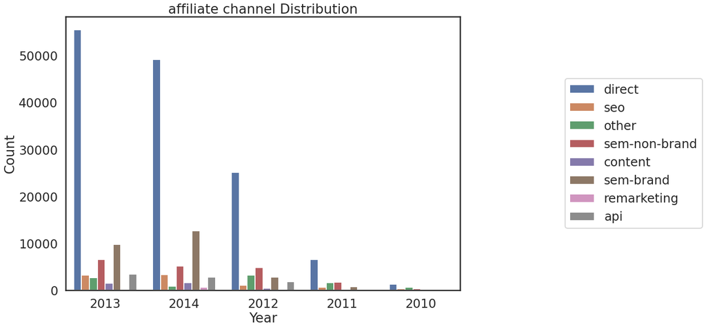

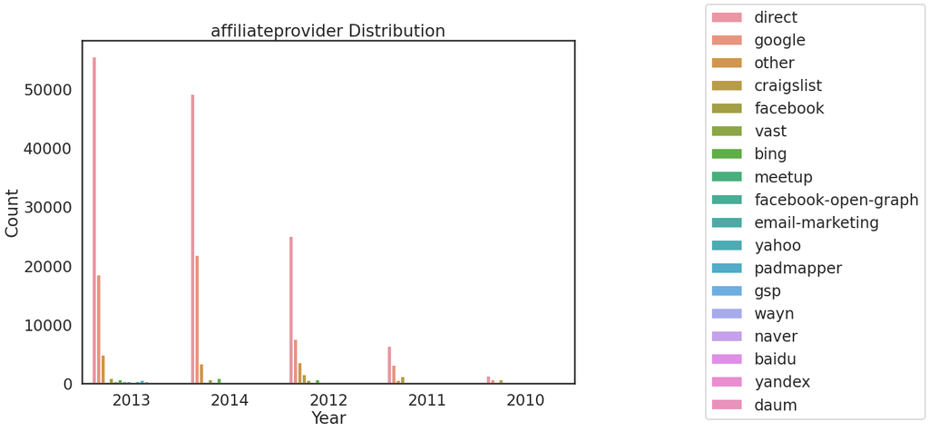

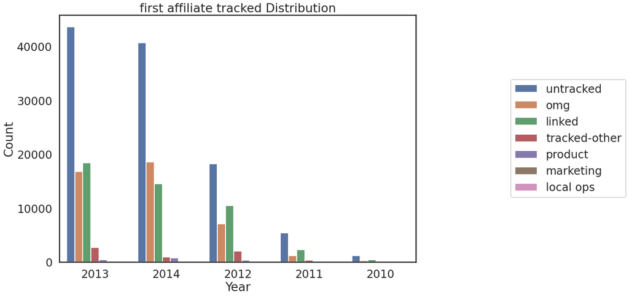

```python
affiliatePlot(train_users,'affiliate_channel','affiliate channel Distribution')
affiliatePlot(train_users,'affiliate_provider','affiliateprovider Distribution')
affiliatePlot(train_users,'first_affiliate_tracked','first affiliate tracked Distribution')
```

```python
train_users.isnull().sum()
```

```
id                              0
date_account_created            0
timestamp_first_active          0
date_first_booking         124543
gender                          0
age                         88949
signup_method                   0
signup_flow                     0
language                        0
affiliate_channel               0
affiliate_provider              0
first_affiliate_tracked      6065
signup_app                      0
first_device_type               0
first_browser                   0
country_destination             0
account_year                    0
dtype: int64
```

```python
train_users.age.unique()
```

```
array([ nan,  38.,  56.,  42.,  41.,  46.,  47.,  50.,  36.,  37.,  33.,
        31.,  29.,  30.,  40.,  26.,  32.,  35.,  59.,  49.,  44.,  34.,
        28.,  19.,  53.,  52.,  39.,  57.,  25.,  54.,  69.,  63.,  43.,
        55.,  65.,  58.,  61.,  18.,  27.,  45.,  60.,  48.,  51.,  64.,
        72.,  70.,  67.,  73., 104.,  66., 105.,  68.,  95.,  24.,  94.,
        75.,  79.,  62.,  23., 101.,  98.,  76.,  74.,  87.,  92.,  71.,
        84., 107.,  78.,  99., 110., 102.,  82.,  77.,  22.,  89.,  21.,
        20., 103.,  86.,  97.,  81.,  90.,  88.,  80., 100.,  91., 106.,
        83.,  85., 108., 109.,  93.,  96.])
```

### Age distrbution

#### Age & Destination

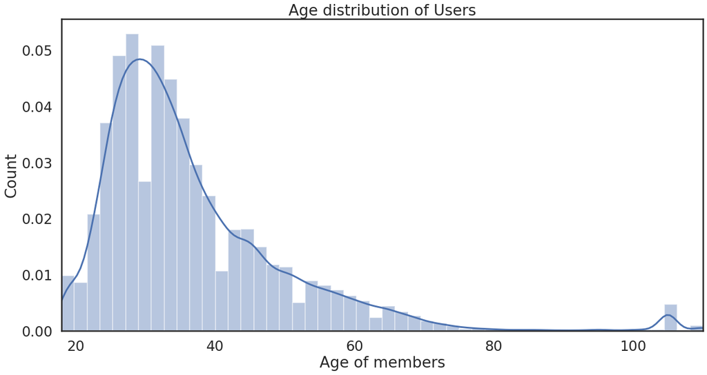

```python
plt.figure(figsize=[20,10])
sns.distplot(all_users.age.dropna());
plt.xlabel('Age of members')
plt.ylabel('Count')
plt.title('Age distribution of Users')
plt.xlim(18,110);
```

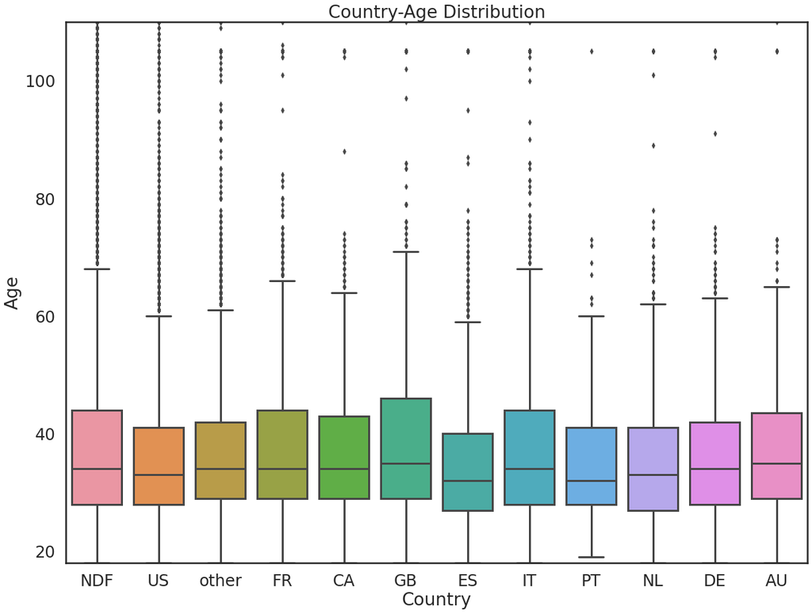

```python
boxPlot(train_users,'age','country_destination',[20,15],'Country','Age','Country-Age Distribution' )
```

**there is no significant age difference among the users booking trips to the destinations displayed in the graph. However, the users booking trips to Great Britain seem to be relatively older than those booking trips to Spain and Netherlands.**

#### Age &Gender

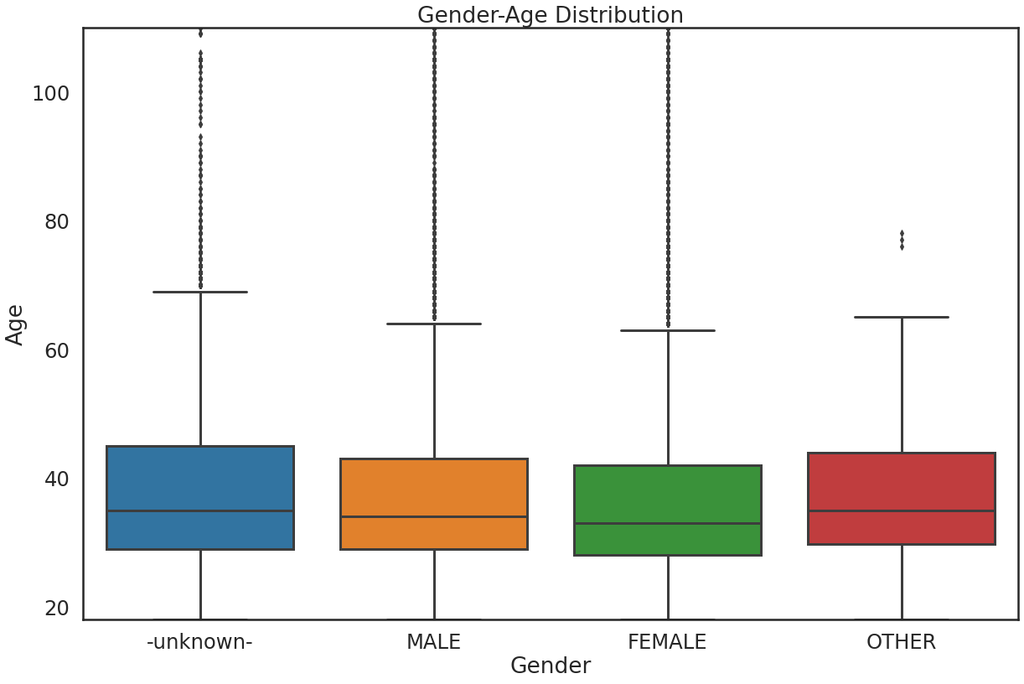

```python
boxPlot(train_users,'age','gender',[20,13],'Gender','Age','Gender-Age Distribution' )
```

```python
all_users.head()
```

|  | affiliate_channel | affiliate_provider | age | date_account_created | first_affiliate_tracked | first_browser | first_device_type | gender | language | signup_app | signup_flow | signup_method | timestamp_first_active | account_year |
| --- | --- | --- | --- | --- | --- | --- | --- | --- | --- | --- | --- | --- | --- | --- |
| 0 | direct | direct | NaN | 2010-06-28 | untracked | Chrome | Mac Desktop | -unknown- | en | Web | 0 | facebook | 2009-03-19 04:32:55 | 2010 |
| 1 | seo | google | 38.0 | 2011-05-25 | untracked | Chrome | Mac Desktop | MALE | en | Web | 0 | facebook | 2009-05-23 17:48:09 | 2011 |
| 2 | direct | direct | 56.0 | 2010-09-28 | untracked | IE | Windows Desktop | FEMALE | en | Web | 3 | basic | 2009-06-09 23:12:47 | 2010 |
| 3 | direct | direct | 42.0 | 2011-12-05 | untracked | Firefox | Mac Desktop | FEMALE | en | Web | 0 | facebook | 2009-10-31 06:01:29 | 2011 |
| 4 | direct | direct | 41.0 | 2010-09-14 | untracked | Chrome | Mac Desktop | -unknown- | en | Web | 0 | basic | 2009-12-08 06:11:05 | 2010 |

### Signup Method

[figure not shown]

```python
countPlot(all_users,'signup_method','signup method',' users signup method Distribution',[15,9])
```

**nearly 70% used the basic method (email) to sign up with Airbnb.**

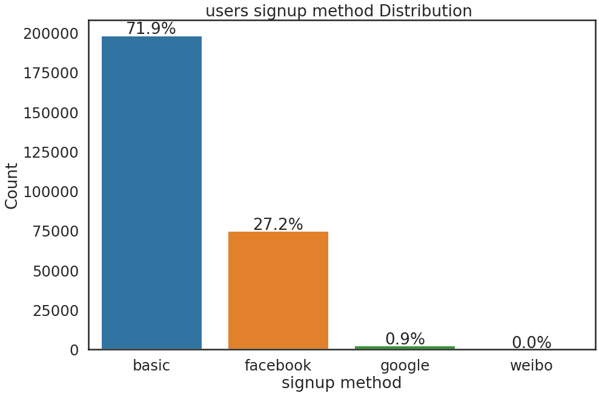

```python
countPlot(all_users,'signup_method','signup method','users signup method Distribution ',[15,10])
```

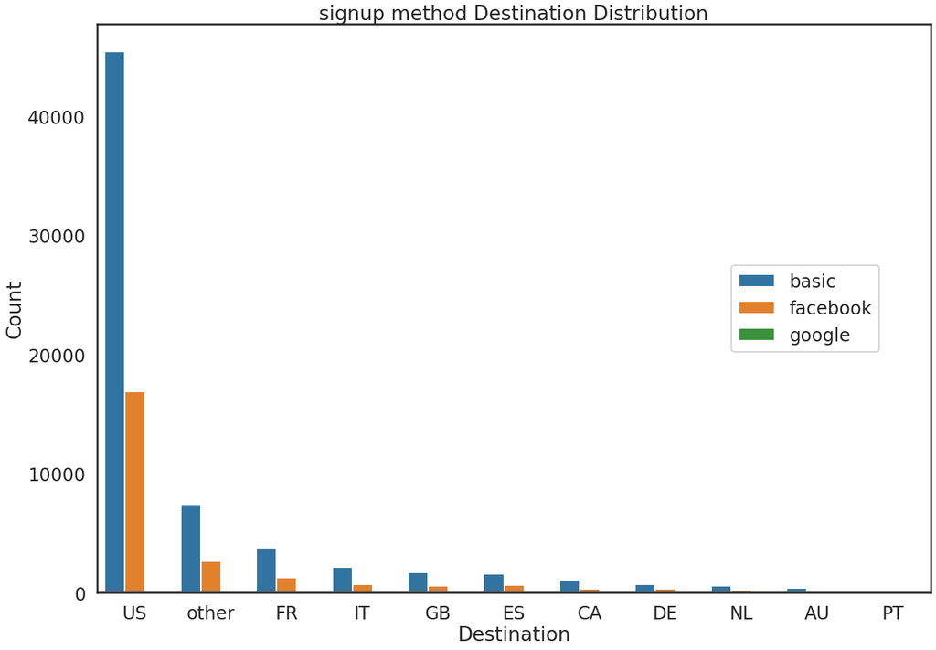

```python
data = train_users[train_users['country_destination']!='NDF']
countplotWithHue(data,'country_destination','Destination','signup method Destination Distribution',[20,14],'signup_method')
```

### sign up Flow

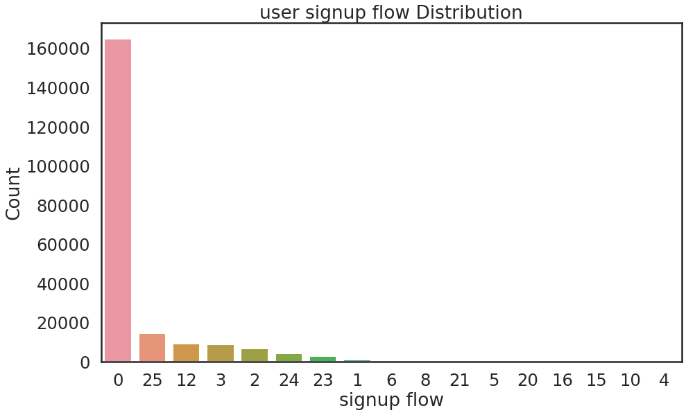

```python
plt.figure(figsize=(15,9))
Order = train_users['signup_flow'].value_counts().index
sns.countplot(data = train_users, x = 'signup_flow', order = Order)
plt.xlabel('signup flow')
plt.ylabel('Count')
plt.title('user signup flow Distribution')
order2 = train_users['signup_flow'].value_counts()
```

### first device type

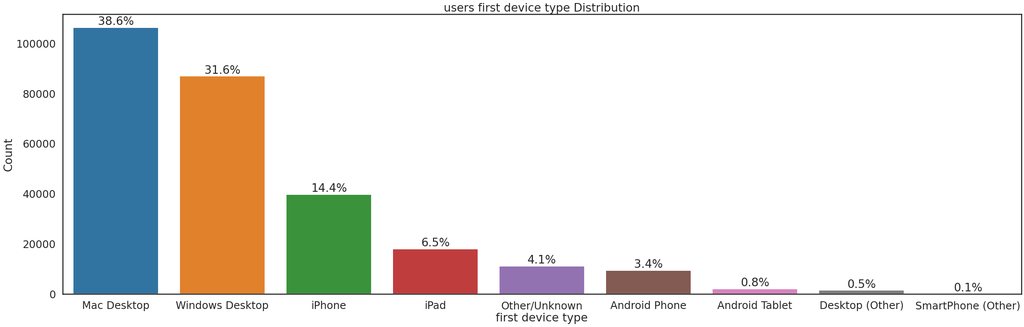

```python
countPlot(all_users,'first_device_type','first device type','users first device type Distribution',[40,12])
```

it seems that the most popular device that users use to first access Airbnb’s website is Mac desktop (40%) followed by Windows desktop (30%).

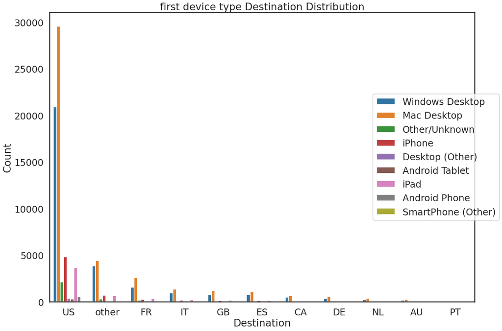

```python
countplotWithHue(data,'country_destination','Destination','first device type Destination Distribution',[20,14],'first_device_type')
```